# Project Submission

2024-05-10

### Import Data

```r
base_data = read_csv("qgdp_training.csv")
data = base_data %>%
  select(Date,
         `Fishing, Aquaculture and Agriculture, Forestry and Fishing Support Services`) %>%
  mutate(Date = yearquarter(Date)) %>%
  rename(FAAFFSS = `Fishing, Aquaculture and Agriculture, Forestry and Fishing Support Services`)
data = as_tsibble(data, index=Date)
rm(list="base_data") #Delete the original dataset
```

### Initialise Surrogate Test Functions

```r
# Function to perform surrogate test for independence
surrogate.test = function(data, lag, N = 1000, test.stat = "ljung-box") {

  # data: a tsibble or numeric vector object
  # lag: number of lags in portmanteau test statistic
  # N: number of permutations to perform
  # test.stat: either "ljung-box" or "box-pierce"

  if (is_tsibble(data)) {
    if (length(measures(data)) != 1) {
      stop("data must be a tsibble with one measurement variable")
    }
    # Extract time series
    data = data %>%
      pull(as.character(measures(data)[[1]]))
  }

  n = length(data)

  Q.null = rep(NA, N)  # Open test statistic vectors

  if (test.stat == "ljung-box") {

    # Observed test statistic
    r.obs = acf(data, plot = FALSE)$acf[2:(lag + 1)]
    Q.obs = n * (n + 2) * sum(r.obs ^ 2 / (n - 1:lag))

    # Null distribution
    for (i in 1:N) {
      surrogate = sample(data, n)  # Permute data (kill autocorrelation, maintain amplitude)
      r = acf(surrogate, plot = FALSE)$acf[2:(lag + 1)]   # Estimate autocorrelation
      Q.null[i] = n * (n + 2) * sum(r ^ 2 / (n - 1:lag))  # Ljung-Box test statistic
    }

  }

  if (test.stat == "box-pierce") {

    # Observed test statistic
    r.obs = acf(data, plot = FALSE)$acf[2:(lag + 1)]
    Q.obs = n * sum(r.obs ^ 2)

    # Null distribution
    for (i in 1:N) {
      surrogate = sample(data, n)  # Permute data (kill autocorrelation, maintain amplitude)
      r = acf(surrogate, plot = FALSE)$acf[2:(lag + 1)]  # Estimate autocorrelation
      Q.null[i] = n * sum(r ^ 2)                         # Box-Pierce test statistic
    }

  }

  # Compute p-value
  p.value = mean(Q.null >= Q.obs)  # p-value

  # Output
  output = list(Q.null = Q.null,
                Q.obs = Q.obs,
                test.stat = test.stat,
                p.value = p.value)

  class(output) = "surrogate"

  return(output)

}


# Function to plot surrogate null distribution and observed test statistic
# Requires ggplot2
plot.surrogate = function(obj, binwidth = 10) {

  # obj: Object of class "surrogate"
  # binwidth: width of the bins for the histogram

  ggplot(data = data.frame(Q = obj$Q.null),
         mapping = aes(x = Q)) +
    geom_histogram(fill = "navy", colour = "black", binwidth = binwidth) +
    geom_vline(xintercept = obj$Q.obs,
               linetype = "dashed") +
    labs(x = "Test statistic",
         y = "Count")

}
```

# Exploratory Analysis

```
## Plot variable not specified, automatically selected `.vars = FAAFFSS`
```

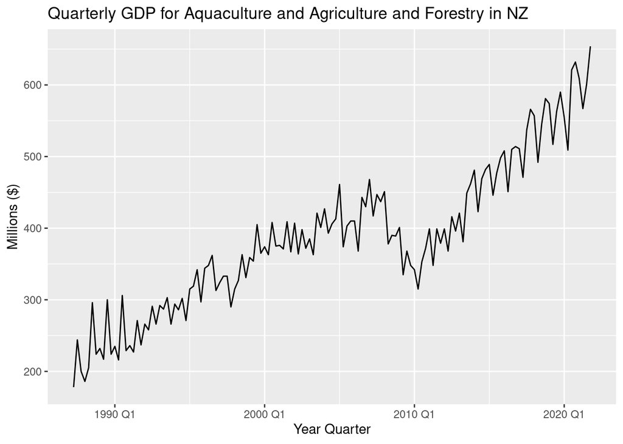

```r
# plots
data %>%
  autoplot() +
  labs(title = "Quarterly GDP for Aquaculture and Agriculture and Forestry in NZ",
       x = "Year Quarter",
       y = "Millions ($)")
```

```r
data %>%
  gg_subseries() +
  labs(title = "Subseries quarterly GDP for Aquaculture and Agriculture and Forestry in NZ",
       x = "Year",
       y = "Millions ($)")
```

```
## Plot variable not specified, automatically selected `y = FAAFFSS`
```

[figure not shown]

```
## Plot variable not specified, automatically selected `y = FAAFFSS`
```

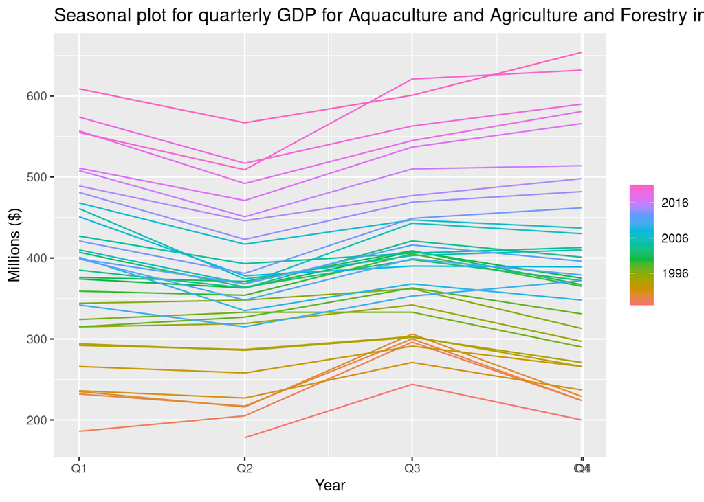

```r
data %>%
  gg_season() +
  labs(title = "Seasonal plot for quarterly GDP for Aquaculture and Agriculture and Forestry in NZ",
       x = "Year",
       y = "Millions ($)")
```

```
## Plot variable not specified, automatically selected `y = FAAFFSS`
```

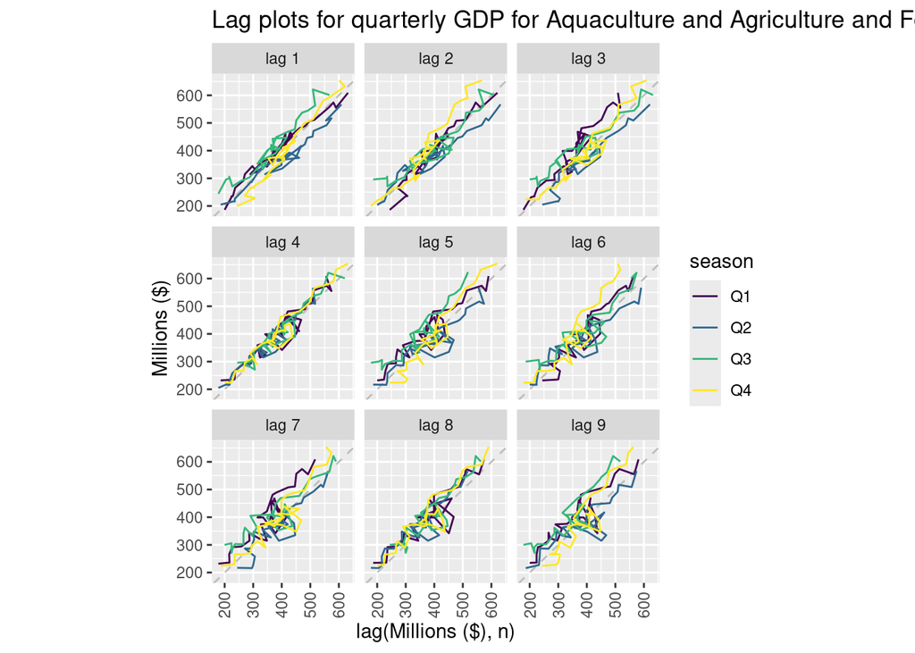

```r
data %>%
  gg_lag() +
  labs(title = "Lag plots for quarterly GDP for Aquaculture and Agriculture and Forestry in NZ",
       x = "lag(Millions ($), n)",
       y = "Millions ($)") +
  theme(axis.text.x = element_text(angle = 90, vjust = 0.5, hjust=1))
```

```
## Response variable not specified, automatically selected `var = FAAFFSS`
```

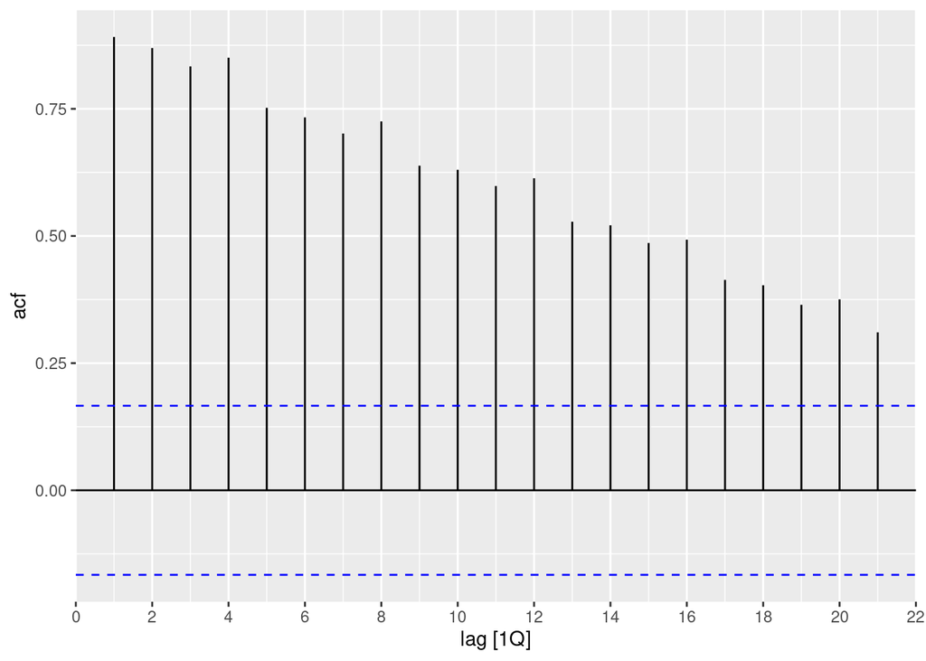

```r
data %>%
  ACF() %>%
  autoplot()
```

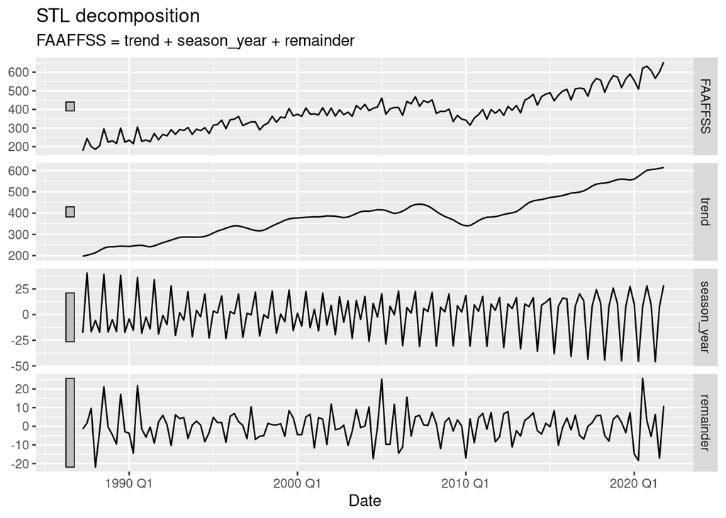

```r
decomposed_data = data %>%
  model(STL(FAAFFSS ))
components(decomposed_data) %>% autoplot()
```

The time plot shows a general steady growth up of GDP until around 2008, the trend dipped for 2 years during the economic crisis before steady growth back up after 2010 Q1 at a faster rate. There appears to be some quarterly seasonality however this seasonality appear to have morphed during the period in this plot. It is a bit difficult to tell from this plot what is happening.

The subseries plot shows the GDP changes by the quarter, the quarter all followed the general pattern discussed earlier. However this plot shows that on average Q2 seems to have the lowest GDP out of all the quarters. Quarters 1, 3, 4 appear to not be to different from each other on average. Q3 seemed to have had a slower growth than the rest up until about 2008. The differences in the quarters suggests a quarterly pattern.

The seasonal plot shows that the are somewhat regular seasonal patterns, however seasonality may have changed throughout the period as suspected previously. Q3 was had the highest GDP during the earlier years and Q2/4 had the lowest GDP. As time progressed the GDP in Q4 became the highest. This plot also shows the general increasing tread with time looking at how later years have higher lines, the jumbled lines in the middle of the graph reflects the GDP decrease during 2008 to 2010.

The lag plots shows that each quarter is strongly correlated with the previous quarter, the fuzzier lines with more lag shows that this correlation weakens with more lag. However on lags divisible by 4, that is the same time in a different year, the correlation becomes a bit stronger than nearby lags, the graph showed the lines are more closely on the diagonal in these lags. So there is a seasonal pattern

The correlation discussed earlier is reflected in the ACF plots. The correlation decreases with more lags but there is a small spike when the lag is divisible by 4, showing a slightly stronger correlation with a lagged version of itself that is at the same time in a different year, ie. a seasonal pattern.

The STL composition highlights that the general trend contributes the most to the series, followed by the seasonality. The residuals contribute almost as much as the seasonality to the series. The general trend agrees what was discussed prior. The seasonality shows a clear change throughout the period, also in line with prior discussion, eg. Q4 GDP has significantly increased in the period. The effect of seasonality appear to have been decreasing initially up to around 2004 before increasing again.

# ETS models

## Methodology to Create a Shortlist of Appropriate Candidate ETS Models

```r
# Check for missing values
missing_values <- data %>% summarise(across(everything(), ~ sum(is.na(.))))
print(paste("There are", nrow(missing_values),"missing values."))
```

[output not shown]

## Manual Model Fitting:

Defining ETS Models: Manually specify and fit a variety of ETS models with different combinations of error (E), trend (T), and seasonality (S) components.

The models are categorized as follows:

Error Component (E): Additive (A) or Multiplicative (M).

Trend Component (T): None (N), Additive (A), Multiplicative (M), or Additive damped (Ad).

Seasonality Component (S): None (N), Additive (A), or Multiplicative (M).

Model Examples: Fit models such as ETS(A, N, N) for Simple Exponential Smoothing, ETS(A, A, N) for Holt’s Linear Trend, and ETS(A, A, A) for Additive Holt-Winters, among others.

```r
# Manually fit different ETS models
# ETS(A,N,N): Model for simple exponential smoothing (SES)
fit_ann <- data %>% model(ETS(FAAFFSS ~ error("A") + trend("N") + season("N")))
# ETS(M,N,N): SES with multiplicative errors
fit_mnn <- data %>% model(ETS(FAAFFSS ~ error("M") + trend("N") + season("N")))
# ETS(A,A,N): A model for Holt’s linear trend method
fit_aan <- data %>% model(ETS(FAAFFSS ~ error("A") + trend("A") + season("N")))
# ETS(M,A,N): Holt’s linear trend method with multiplicative errors
fit_man <- data %>% model(ETS(FAAFFSS ~ error("M") + trend("A") + season("N")))
fit_amn <- data %>% model(ETS(FAAFFSS ~ error("A") + trend("M") + season("N")))
fit_mmn <- data %>% model(ETS(FAAFFSS ~ error("M") + trend("M") + season("N")))
fit_ana <- data %>% model(ETS(FAAFFSS ~ error("A") + trend("N") + season("A")))
fit_mna <- data %>% model(ETS(FAAFFSS ~ error("M") + trend("N") + season("A")))
fit_aaa <- data %>% model(ETS(FAAFFSS ~ error("A") + trend("A") + season("A")))
fit_maa <- data %>% model(ETS(FAAFFSS ~ error("M") + trend("A") + season("A")))
fit_ama <- data %>% model(ETS(FAAFFSS ~ error("A") + trend("M") + season("A")))
fit_mma <- data %>% model(ETS(FAAFFSS ~ error("M") + trend("M") + season("A")))
fit_anm <- data %>% model(ETS(FAAFFSS ~ error("A") + trend("N") + season("M")))
fit_mnm <- data %>% model(ETS(FAAFFSS ~ error("M") + trend("N") + season("M")))
fit_aam <- data %>% model(ETS(FAAFFSS ~ error("A") + trend("A") + season("M")))
fit_mam <- data %>% model(ETS(FAAFFSS ~ error("M") + trend("A") + season("M")))
fit_amm <- data %>% model(ETS(FAAFFSS ~ error("A") + trend("M") + season("M")))
fit_mmm <- data %>% model(ETS(FAAFFSS ~ error("M") + trend("M") + season("M")))
fit_adn <- data %>% model(ETS(FAAFFSS ~ error("A") + trend("Ad") + season("N")))
fit_mdn <- data %>% model(ETS(FAAFFSS ~ error("M") + trend("Ad") + season("N")))
fit_ada <- data %>% model(ETS(FAAFFSS ~ error("A") + trend("Ad") + season("A")))
fit_mda <- data %>% model(ETS(FAAFFSS ~ error("M") + trend("Ad") + season("A")))
fit_adm <- data %>% model(ETS(FAAFFSS ~ error("A") + trend("Ad") + season("M")))
fit_mdm <- data %>% model(ETS(FAAFFSS ~ error("M") + trend("Ad") + season("M")))
```

## Automatic Model Selection:

Using Automated ETS: Utilize the ETS function to automatically fit the best ETS model based on information criteria like AICc (Akaike Information Criterion corrected for small sample sizes).

```r
# Automatically fit the ETS model
fit_auto <- data %>% model(ETS(FAAFFSS))
report(fit_auto)
```

```
## Series: FAAFFSS
## Model: ETS(M,A,M)
##   Smoothing parameters:
##     alpha = 0.5044422
##     beta  = 0.007167769
##     gamma = 0.4955577
##
##   Initial states:
##      l[0]     b[0]      s[0]     s[-1]    s[-2]     s[-3]
##  193.4443 5.672164 0.8798408 0.9597361 1.256635 0.9037881
##
##   sigma^2:  0.0027
##
##      AIC     AICc      BIC
## 1518.864 1520.260 1545.275
```

## Model Comparison:

Calculating AICc Values: For each manually fitted model and the automatically selected model, compute the AICc value. The AICc penalizes model complexity to prevent overfitting and is useful for comparing models.

Ranking Models: Create a list of all candidate models along with their AICc values. Sort the models by AICc in ascending order to identify the best-performing models.

Choosing the Lowest AICc Model: Select the model with the lowest AICc value as the best model. This model is expected to balance goodness of fit and model complexity.

```r
# Compare models using AICc
aic_values <- bind_rows(
  glance(fit_aaa) %>% mutate(Model = "AAA"),
  glance(fit_ann) %>% mutate(Model = "ANN"),
  glance(fit_mnn) %>% mutate(Model = "MNN"),
  glance(fit_aan) %>% mutate(Model = "AAN"),
  glance(fit_man) %>% mutate(Model = "MAN"),
  glance(fit_amn) %>% mutate(Model = "AMN"),
  glance(fit_mmn) %>% mutate(Model = "MMN"),
  glance(fit_ana) %>% mutate(Model = "ANA"),
  glance(fit_mna) %>% mutate(Model = "MNA"),
  glance(fit_maa) %>% mutate(Model = "MAA"),
  glance(fit_ama) %>% mutate(Model = "AMA"),
  glance(fit_mma) %>% mutate(Model = "MMA"),
  glance(fit_anm) %>% mutate(Model = "ANM"),
  glance(fit_mnm) %>% mutate(Model = "MNM"),
  glance(fit_aam) %>% mutate(Model = "AAM"),
  glance(fit_mam) %>% mutate(Model = "MAM"),
  glance(fit_mmm) %>% mutate(Model = "MMM"),
  glance(fit_amm) %>% mutate(Model = "AMM"),
  glance(fit_adn) %>% mutate(Model = "AAdN"),
  glance(fit_mdn) %>% mutate(Model = "MAdN"),
  glance(fit_ada) %>% mutate(Model = "AAdA"),
  glance(fit_mda) %>% mutate(Model = "MAdA"),
  glance(fit_adm) %>% mutate(Model = "AAdM"),
  glance(fit_mdm) %>% mutate(Model = "MAdM"),
  glance(fit_auto) %>% mutate(Model = "AUTO_MAM"),
) %>% select(Model, AICc) %>% arrange(AICc)

knitr::kable(aic_values)
```

| Model | AICc |
| --- | --- |
| MAM | 1520.260 |
| AUTO_MAM | 1520.260 |
| MAdM | 1520.394 |
| AAM | 1522.644 |
| AMM | 1524.073 |
| AAA | 1526.729 |
| AAdM | 1527.659 |
| AMA | 1528.734 |
| MMM | 1530.183 |
| ANM | 1530.458 |
| MAA | 1531.212 |
| AAdA | 1532.881 |
| ANA | 1538.268 |
| MNM | 1543.496 |
| MMA | 1543.846 |
| MAdA | 1544.422 |
| MNA | 1547.804 |
| AAN | 1649.688 |
| AMN | 1649.707 |
| AAdN | 1653.189 |
| ANN | 1655.655 |
| MAN | 1669.362 |
| MAdN | 1671.170 |
| MMN | 1673.251 |
| MNN | 1679.913 |

## Reasons for Selecting the ETS(MAM) Model: Lowest AICc Value

Model Comparison: Among the various manually fitted models and the automatically selected model, ETS(MAM) was found to have the lowest AICc value. The AICc (Akaike Information Criterion corrected for small sample sizes) is a measure of the relative quality of statistical models for a given set of data. It considers both the goodness of fit and the complexity of the model (penalizing for the number of parameters). A lower AICc value indicates a better balance between model fit and complexity.

Statistical Justification: Selecting the model with the lowest AICc helps in minimizing overfitting while ensuring that the model adequately captures the underlying patterns in the data.

```r
# Select the best model based on the lowest AICc value
best_model <- fit_mam
report(best_model)
```

```
## Series: FAAFFSS
## Model: ETS(M,A,M)
##   Smoothing parameters:
##     alpha = 0.5044422
##     beta  = 0.007167769
##     gamma = 0.4955577
##
##   Initial states:
##      l[0]     b[0]      s[0]     s[-1]    s[-2]     s[-3]
##  193.4443 5.672164 0.8798408 0.9597361 1.256635 0.9037881
##
##   sigma^2:  0.0027
##
##      AIC     AICc      BIC
## 1518.864 1520.260 1545.275
```

## In an ETS(MAM) model:

E stands for the error term, which is multiplicative.

T stands for the trend component, which is additive.

S stands for the seasonal component, which is multiplicative.

The general form of the ETS(MAM) model equations are:
$$y_t = (l_{t-1} + b_{t-1})s_{t-m}(1+ϵ_t)$$
$$l_t = (l_{t-1} + b_{t-1})(1+αϵ_t)$$
$$b_t = b_{t-1} + β(l_{t-1}+b_{t-1})ϵ_t$$
$$s_t = s_{t-m} (1+γϵ_t)$$
Where:

$y_t$ is the observed value at time t.

$l_t$ is the level component at time t.

$b_t$ is the trend component at time t.

$s_t$ is the seasonal component at time t.

α, β, and γ are the smoothing parameters for the level, trend, and seasonal components, respectively.

m is the period of seasonality.

```r
# Plot the fitted values
best_model %>% augment()
```

```
## # A tsibble: 139 x 6 [1Q]
## # Key:       .model [1]
##    .model                                  Date FAAFFSS .fitted  .resid   .innov
##    <chr>                                  <qtr>   <dbl>   <dbl>   <dbl>    <dbl>
##  1 "ETS(FAAFFSS ~ error(\"M\") + trend… 1987 Q2     178    180.  -1.96  -0.0109
##  2 "ETS(FAAFFSS ~ error(\"M\") + trend… 1987 Q3     244    256. -12.0   -0.0467
##  3 "ETS(FAAFFSS ~ error(\"M\") + trend… 1987 Q4     200    196.   3.76   0.0192
##  4 "ETS(FAAFFSS ~ error(\"M\") + trend… 1988 Q1     186    187.  -0.583 -0.00313
##  5 "ETS(FAAFFSS ~ error(\"M\") + trend… 1988 Q2     205    195.   9.63   0.0493
##  6 "ETS(FAAFFSS ~ error(\"M\") + trend… 1988 Q3     296    280.  15.6    0.0556
##  7 "ETS(FAAFFSS ~ error(\"M\") + trend… 1988 Q4     224    233.  -9.12  -0.0391
##  8 "ETS(FAAFFSS ~ error(\"M\") + trend… 1989 Q1     232    212.  19.8    0.0932
##  9 "ETS(FAAFFSS ~ error(\"M\") + trend… 1989 Q2     217    238. -21.3   -0.0895
## 10 "ETS(FAAFFSS ~ error(\"M\") + trend… 1989 Q3     300    319. -18.9   -0.0593
## # ℹ 129 more rows
```

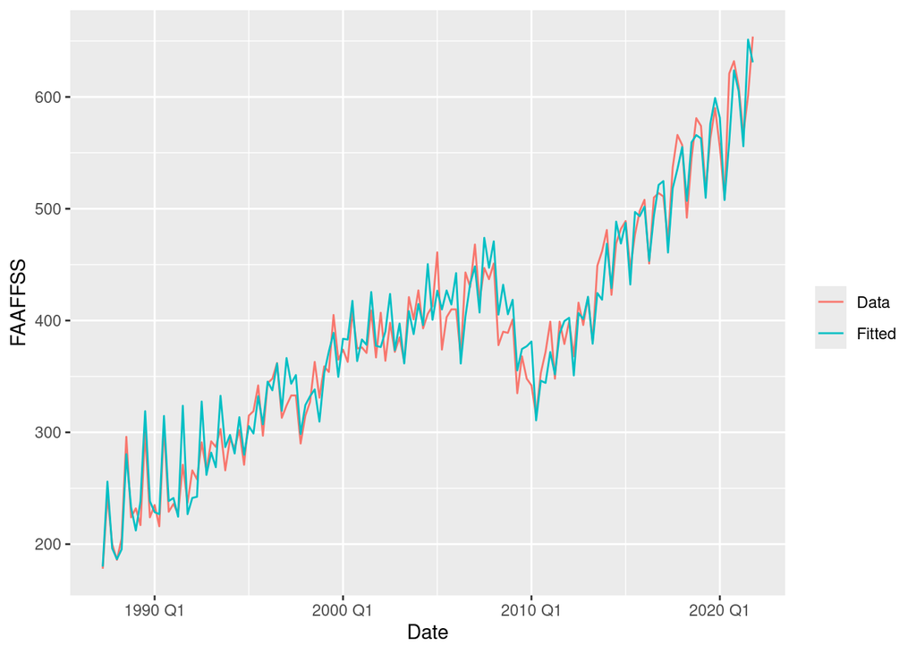

```r
augment(best_model) %>%
ggplot(aes(x = Date)) +
geom_line(aes(y = FAAFFSS, colour = "Data")) +
geom_line(aes(y = .fitted, colour = "Fitted")) +
guides(colour = guide_legend(title = ""))
```

## Model Diagnostics:

Residual Analysis: Perform residual diagnostics on the selected model to ensure that the residuals behave like white noise (i.e., they are uncorrelated and have constant variance).

Components Decomposition: Decompose the selected model to inspect its components (level, trend, and seasonality) for better understanding and validation.

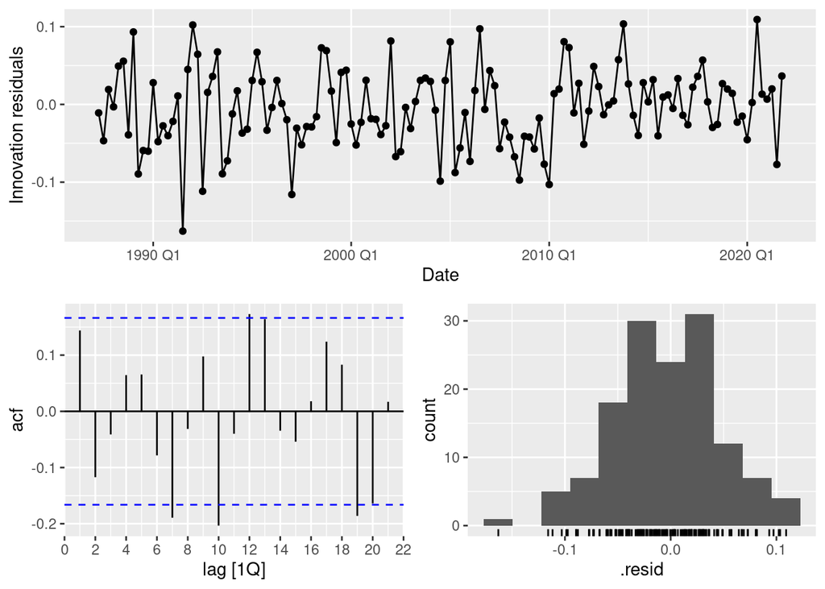

```r
# Residual diagnostics
best_model %>% gg_tsresiduals()
```

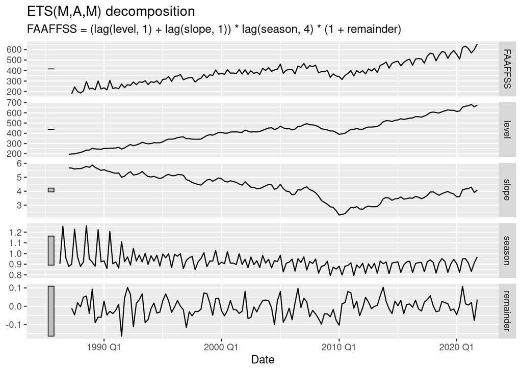

```r
# Components Decomposition
best_model %>%
  components() %>%
  autoplot()
```

### Generate ETS Forecasts

```r
# Generate forecasts
forecast_data <- best_model %>% forecast(h = 8)
forecast_data
```

```
## # A fable: 8 x 4 [1Q]
## # Key:     .model [1]
##   .model                                                 Date      FAAFFSS .mean
##   <chr>                                                 <qtr>       <dist> <dbl>
## 1 "ETS(FAAFFSS ~ error(\"M\") + trend(\"A\") + seaso… 2022 Q1 N(617, 1014)  617.
## 2 "ETS(FAAFFSS ~ error(\"M\") + trend(\"A\") + seaso… 2022 Q2 N(569, 1085)  569.
## 3 "ETS(FAAFFSS ~ error(\"M\") + trend(\"A\") + seaso… 2022 Q3 N(628, 1599)  628.
## 4 "ETS(FAAFFSS ~ error(\"M\") + trend(\"A\") + seaso… 2022 Q4 N(670, 2142)  670.
## 5 "ETS(FAAFFSS ~ error(\"M\") + trend(\"A\") + seaso… 2023 Q1 N(632, 3011)  632.
## 6 "ETS(FAAFFSS ~ error(\"M\") + trend(\"A\") + seaso… 2023 Q2 N(583, 2807)  583.
## 7 "ETS(FAAFFSS ~ error(\"M\") + trend(\"A\") + seaso… 2023 Q3 N(643, 3733)  643.
## 8 "ETS(FAAFFSS ~ error(\"M\") + trend(\"A\") + seaso… 2023 Q4 N(686, 4609)  686.
```

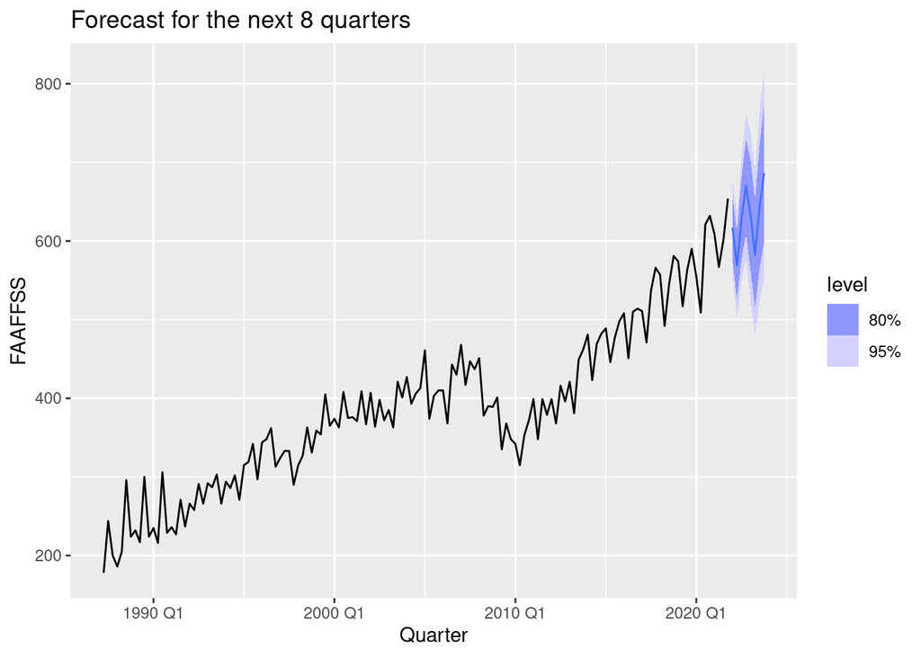

```r
forecast_data %>% autoplot(data) +
  labs(title = "Forecast for the next 8 quarters", x = "Quarter", y = "FAAFFSS")
```

## Explanation of Prediction Intervals

An advantage of ETS models is that prediction intervals can be constructed. Prediction intervals will differ between additive and multiplicative error models.

For ETS(A,N/A/Ad,N/A) models prediction distributions are Gaussian.

For ETS(M,N/A/Ad,N/A/M) models prediction distributions are non-Gaussian because of nonlinearity of the state space equations.

Gaussian approximation usually give reasonably accurate results.

If this approximation is not reasonable, we can generate future sample paths conditional on the last estimate of the states, and then to obtain prediction intervals from the percentiles of these simulated future paths.

In the ETS model, the prediction interval is calculated based on the variance of the residuals. The ETS (MAM) model is a multiplicative error model, and the calculation of its prediction interval takes into account the gradual accumulation of prediction errors. Specifically, the prediction interval is calculated through the following steps:

Calculate point prediction value: Based on the parameters of the ETS model and input data at future time points, calculate the future point prediction value.

Estimate the variance of the forecast error: Use the variance of the residuals to estimate the variance of the forecast error. For the multiplicative error model, the variance of the error increases with forecast time.

Calculate the prediction interval: Based on the variance of the prediction error and using the assumption of normal distribution, calculate the prediction interval at different confidence levels.

In R, these steps are completed automatically by the forecast function, we only need to specify the forecast time range h.

```r
# Assuming `best_model` is the ETS(MAM) model we selected earlier
residuals_data <- best_model %>% augment() %>% pull(.resid)

# Convert residuals to a tsibble for testing
residuals_tsibble <- tsibble(Residuals = residuals_data, Date = data$Date, index = Date)

# Perform surrogate test
s = surrogate.test(residuals_tsibble, lag = 10, N = 1000, test.stat = "ljung-box")

# Extract p-value
s$p.value
```

```
## [1] 0.224
```

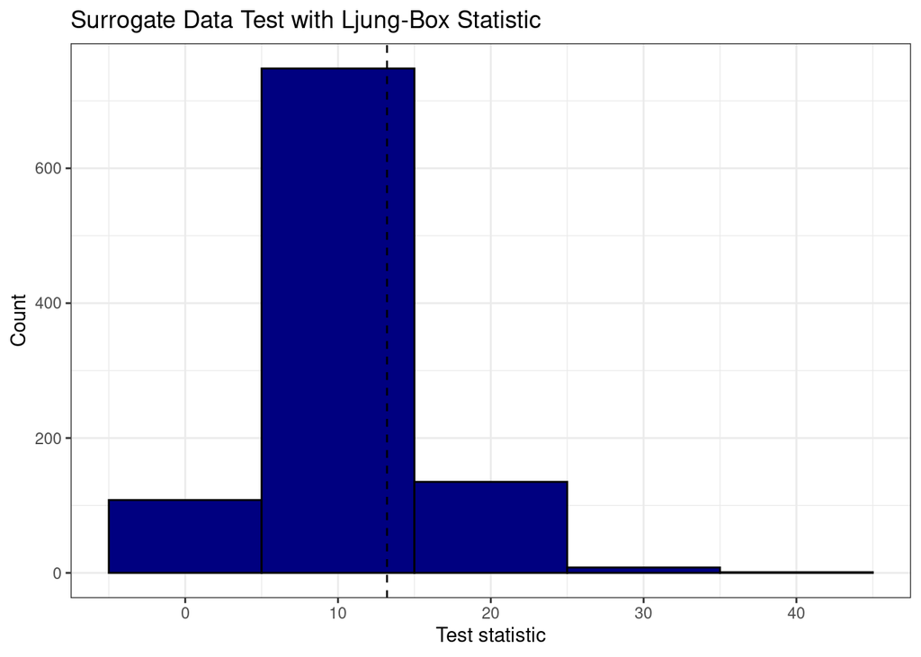

```r
# Plot the surrogate null distribution and observed test statistic
s %>% plot.surrogate() + theme_bw() + labs(title = "Surrogate Data Test with Ljung-Box Statistic")
```

## Explanation of the Surrogate Test for Independence

The provided R code implements a surrogate test for independence on a time series dataset. This test is designed to determine if the residuals (or innovation residuals) of a model are independent, which is a key assumption in time series analysis. The surrogate test does this by comparing the observed autocorrelation structure of the residuals to a distribution of autocorrelation structures obtained from permuted (shuffled) versions of the data.

### Interpretation of the p-value

In the context of the surrogate test for independence, the p-value is used to determine whether we can reject the null hypothesis that the residuals are independent. The null hypothesis states that the residuals are independent (i.e., there is no significant autocorrelation in the residuals).

### Significance Level

A common significance level used in hypothesis testing is 0.05 (5%). If the p-value is less than 0.05, we reject the null hypothesis and conclude that there is significant autocorrelation in the residuals. If the p-value is greater than or equal to 0.05, we fail to reject the null hypothesis and conclude that there is no significant autocorrelation in the residuals.

Since the p-value of our model is greater than the typical significance level of 0.05, we do not have enough evidence to reject the null hypothesis. This means that:

The residuals of the ETS(MAM) model do not show significant autocorrelation. The residuals can be considered independent.

### Conclusion

The result of the surrogate test suggests that the residuals from the ETS(MAM) model are independent. This is a good outcome as it implies that the model has adequately captured the structure in the data, leaving behind residuals that behave like white noise, which is an important assumption in time series modeling.

```r
# Load the test data set
test_data <- read.csv("qgdp_full.csv")

# Prepare the test data
test_data <- test_data %>%
  select(Date, `Fishing..Aquaculture.and.Agriculture..Forestry.and.Fishing.Support.Services`) %>%
  mutate(Date = yearquarter(Date)) %>%
  rename(FAAFFSS = `Fishing..Aquaculture.and.Agriculture..Forestry.and.Fishing.Support.Services`)
test_data <- as_tsibble(test_data, index = Date)

# Extract the relevant part of the test data (2022 Q1 to 2023 Q4)
test_data_subset <- test_data %>%
  filter(Date >= yearquarter("2022 Q1") & Date <= yearquarter("2023 Q4"))

# Merge forecasts with actual test data
comparison_data <- forecast_data %>%
  left_join(test_data_subset, by = "Date") %>%
  rename(Forecast = .mean, Actual = FAAFFSS.y) %>%
  select(Date, Forecast, Actual)

# Calculate accuracy metrics
accuracy_metrics <- accuracy(comparison_data$Forecast, comparison_data$Actual)

# Print accuracy metrics
knitr::kable(accuracy_metrics)
```

|  | ME | RMSE | MAE | MPE | MAPE |
| --- | --- | --- | --- | --- | --- |
| Test set | 9.280548 | 19.54906 | 16.67565 | 1.539261 | 2.654215 |

## Discussion on Model Performance

The ETS(MAM) model’s performance in forecasting the GDP values for the “Fishing, Aquaculture, and Agriculture, Forestry, and Fishing Support Services” sector from 2022 Q1 to 2023 Q4 is evaluated using several accuracy metrics.

#### Overall Performance

The ETS(MAM) model demonstrates a strong performance in forecasting the GDP for the sector in question. The low values of ME, MAE, MPE, and MAPE indicate that the model’s forecasts are generally accurate and close to the actual values. The RMSE, while slightly higher, suggests that there are some larger errors, but they do not dominate the overall accuracy.

#### Strengths and Limitations

Limitations: The RMSE suggests that there are a few instances of larger errors. These may need further investigation to understand and potentially refine the model. The model could be improved by incorporating additional factors or using alternative modelling techniques to further reduce the forecast errors.

In conclusion, the ETS(MAM) model provides reliable forecasts for the GDP values of the “Fishing, Aquaculture, and Agriculture, Forestry, and Fishing Support Services” sector, with a high degree of accuracy and only minor bias. Continuous monitoring and refinement could enhance the model’s performance further.

# Arima Models

## Explore different ARIMA models

### Explain any transformations or differencing required

From data autoplot graph, we can see:

3.there is an upward trend indicates that the mean of the series is not constant over time. So we would need to do first difference to make the series stationary in terms of the trend. However, as the data has a strong seasonal pattern, we will apply seasonal differencing first, because sometimes the resulting series will be stationary and there will be no need for a further first difference.

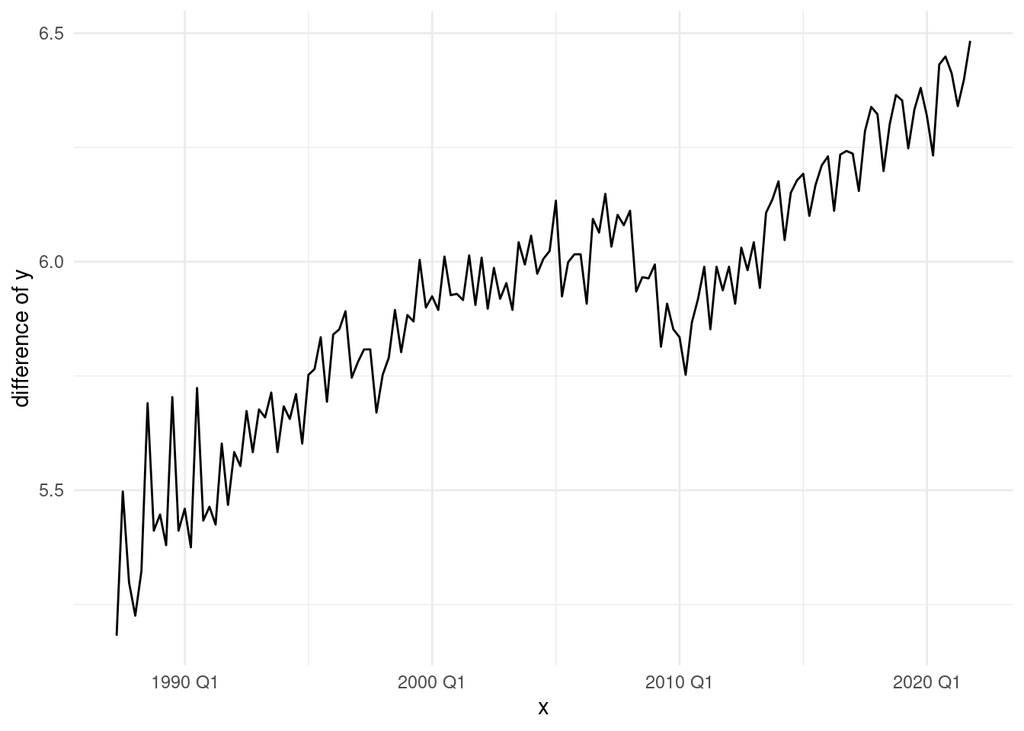

```r
# Log transform to remove the non-constant variance.

data %>%
  autoplot(log(FAAFFSS) ) +
  labs(x = "x", y = "difference of y") +
  theme_minimal()
```

We can see that the log transformation of the data removed the large change in variability and made the variance roughly concept, perhaps except for the first few peaks around 1990.

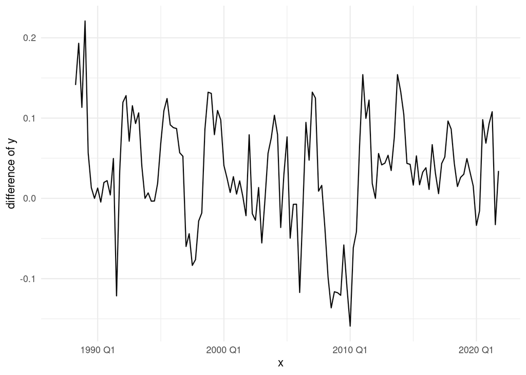

```r
# differencing seasonality

data %>%
  autoplot(log(FAAFFSS) %>% difference(lag=4)) +
  labs(x = "x", y = "difference of y") +
  theme_minimal()
```

After differencing seasonality, we can’t see any non stationary patterns now. we removed the autocorrelation in seasonality. It also shows flat trend and the mean is roughly constant, which suggests we removed the trend by seasonal differencing and we don’t need to to first order difference anymore. So we have a stationary time series.

```r
# test if now the time series data are stationary and non-seasonaly with KPSS test
data  %>%
  features(FAAFFSS , unitroot_kpss)
```

```
## # A tibble: 1 × 2
##   kpss_stat kpss_pvalue
##       <dbl>       <dbl>
## 1      2.47        0.01
```

```r
data  %>%
  features(log(FAAFFSS)%>%difference(4)%>%difference(1) , unitroot_kpss)
```

```
## # A tibble: 1 × 2
##   kpss_stat kpss_pvalue
##       <dbl>       <dbl>
## 1    0.0311         0.1
```

Or we can test how many differences we need to do to get a stationary time series. It shows 1 is enough, which with aligns with what we have already seen.

```r
data %>%
features(FAAFFSS, unitroot_ndiffs)
```

```
## # A tibble: 1 × 1
##   ndiffs
##    <int>
## 1      1
```

```r
data %>%
mutate(log_fa = log(FAAFFSS)) %>%
features(log_fa, feat_stl)
```

```
## # A tibble: 1 × 9
##   trend_strength seasonal_strength_year seasonal_peak_year seasonal_trough_year
##            <dbl>                  <dbl>              <dbl>                <dbl>
## 1          0.992                  0.869                  2                    1
## # ℹ 5 more variables: spikiness <dbl>, linearity <dbl>, curvature <dbl>,
## #   stl_e_acf1 <dbl>, stl_e_acf10 <dbl>
```

```r
data %>%
features(FAAFFSS, unitroot_nsdiffs)
```

```
## # A tibble: 1 × 1
##   nsdiffs
##     <int>
## 1       1
```

### Describe methodology used to create a shortlist of appropriate candidate ARIMA models (Fit both manually & automatically)

Now we will check on the acf and pacf to help us decide appropriate candidate ARIMA models.

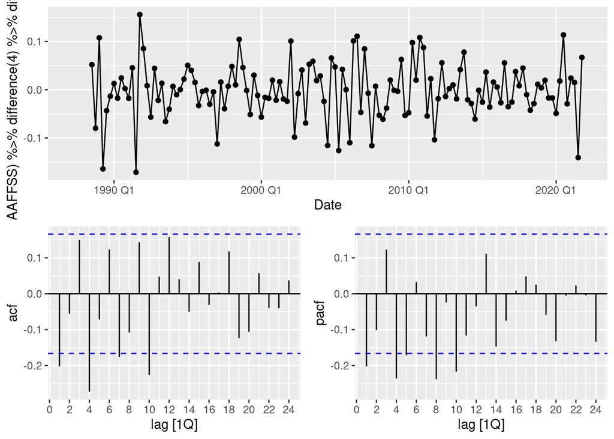

```r
data %>%gg_tsdisplay( log(FAAFFSS) %>% difference(4)%>% difference(1) , plot_type = "partial",lag_max = 24)
```

First we look at the seasonal terms: we focuse on lags that are multiples of the seasonal period ( lag 4, lag 8, lag 12, etc., for a quarterly series with a period of 4).

- For the autoregression process, we check the pacf plot and see that the significant peaks up to 2 and no significant peaks afterwards. it suggest 2 seasonal autoregressive terms. (P=2)
- Likewise,for the moving average process, we check the acf plot and see significant peaks up to the order of 1 and no significant peaks afterwards. it suggest 1 moving average terms.(Q=1)

Next we look at the non-seasonal terms: we will restrict to the lags lower than our seasonal frequency of 4.

- For the autoregression process,we see there are only 1 peaks. it suggest 1 autoregressive terms. (p=1)
- For the moving average process, we see there are only 1 peaks. it suggest 1 autoregressive terms. (q=1)

We can summarise as : Non-seasonal: ARIMA(1, 1, 1); Seasonal: (2, 1, 1)[4]

```r
# we add the manual fit and automatical fit together. p is autoregression,q is moving average

fit <- data %>%
  model(arima_110210 = ARIMA(log(FAAFFSS) ~ pdq(1, 1, 0) + PDQ(2, 1, 0)),
        arima_110011 = ARIMA(log(FAAFFSS) ~ pdq(1, 1, 0) + PDQ(0, 1, 1)),
        arima_011210 = ARIMA(log(FAAFFSS) ~ pdq(0, 1, 1) + PDQ(2, 1, 0)),
        arima_011011 = ARIMA(log(FAAFFSS) ~ pdq(0, 1, 1) + PDQ(0, 1, 1)),
        stepwise = ARIMA(log(FAAFFSS)),
        search = ARIMA(log(FAAFFSS), stepwise = FALSE))
```

## Select the best model & explain why

We compare the result of both manual and auto fit ARIMA model and select the model with smallest AICc as the best model. Here we will select the auto fitted one “search” as our best model.

```r
glance(fit) %>%
  arrange(AICc) %>%
  select(.model:BIC) %>%
  knitr::kable()
```

| .model | sigma2 | log_lik | AIC | AICc | BIC |
| --- | --- | --- | --- | --- | --- |
| search | 0.0024368 | 217.4325 | -418.8649 | -417.7221 | -395.6227 |
| stepwise | 0.0025508 | 212.5361 | -417.0722 | -416.7645 | -405.4511 |
| arima_011210 | 0.0026980 | 207.1489 | -406.2978 | -405.9877 | -394.7065 |
| arima_011011 | 0.0027717 | 205.0209 | -404.0417 | -403.8571 | -395.3482 |
| arima_110210 | 0.0027490 | 205.9847 | -403.9695 | -403.6594 | -392.3781 |
| arima_110011 | 0.0028107 | 204.1413 | -402.2826 | -402.0980 | -393.5891 |

```r
# Report best model
fit %>%
  select(search) %>%
  report()
```

```
## Series: FAAFFSS
## Model: ARIMA(4,0,2)(0,1,0)[4] w/ drift
## Transformation: log(FAAFFSS)
##
## Coefficients:
##          ar1      ar2     ar3      ar4     ma1     ma2  constant
##       0.0877  -0.2112  0.5777  -0.2686  0.6092  0.7034    0.0271
## s.e.  0.1518   0.1036  0.0946   0.1033  0.1455  0.1344    0.0095
##
## sigma^2 estimated as 0.002437:  log likelihood=217.43
## AIC=-418.86   AICc=-417.72   BIC=-395.62
```

### Write the model equation in backshift notation

The best model specifies an ARIMA(4,0,2)(0,1,0)[4] model, which means:

#### Model Components

- $p = 4$: Number of autoregressive terms
- $d = 0$: Degree of non-seasonal differencing
- $q = 2$: Number of moving average terms
- $P = 0$: Number of seasonal autoregressive terms
- $D = 1$: Degree of seasonal differencing
- $Q = 0$: Number of seasonal moving average terms
- $s = 4$: Seasonal period

The backshift operator $B$ is defined as $B^k y_t = y_{t-k}$. Using this notation, the model can be written as:

##### Seasonal Differencing

$$(1 - B^4) y_t = y_t - y_{t-4}$$

##### Non-Seasonal Part

The non-seasonal part of the ARIMA model with autoregressive (AR) and moving average (MA) terms is:

$$(1 - \phi_1 B - \phi_2 B^2 - \phi_3 B^3
- \phi_4 B^4) (1 - B^4) y_t = (1 + \theta_1 B + \theta_2 B^2) \epsilon_t$$

where: - $\phi_1, \phi_2, \phi_3, \phi_4$ are the autoregressive parameters - $\theta_1, \theta_2$ are the moving average parameters - $\epsilon_t$ is the white noise error term

Putting it all together, the ARIMA(4,0,2)(0,1,0)[4] model is:

$$(1 - \phi_1 B - \phi_2 B^2 - \phi_3 B^3
- \phi_4 B^4) (1 - B^4) y_t = (1 + \theta_1 B + \theta_2 B^2) \epsilon_t$$

### Produce residual diagnostic plots

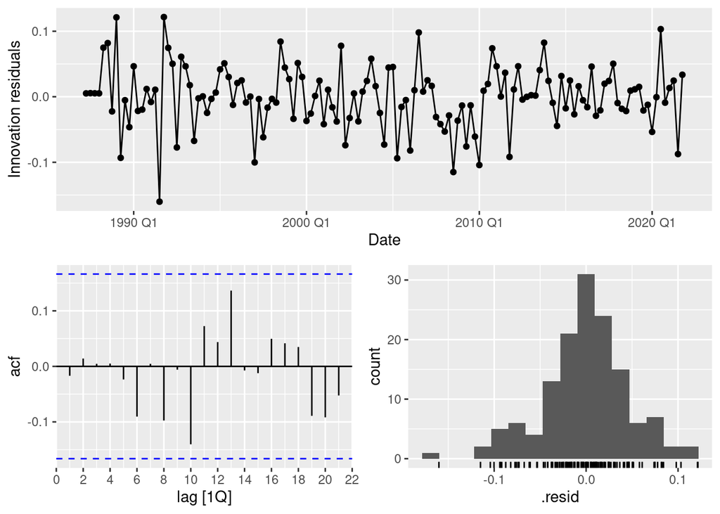

```r
# Check residuals
fit %>%
  select(search) %>%
  gg_tsresiduals()
```

```r
fit %>%
  select(search) %>%
  augment()%>%
  features(.resid,ljung_box,lag=8,dof=7)
```

```
## # A tibble: 1 × 3
##   .model lb_stat lb_pvalue
##   <chr>    <dbl>     <dbl>
## 1 search    4.11    0.0427
```

### Produce forecasts for h=8 quarters

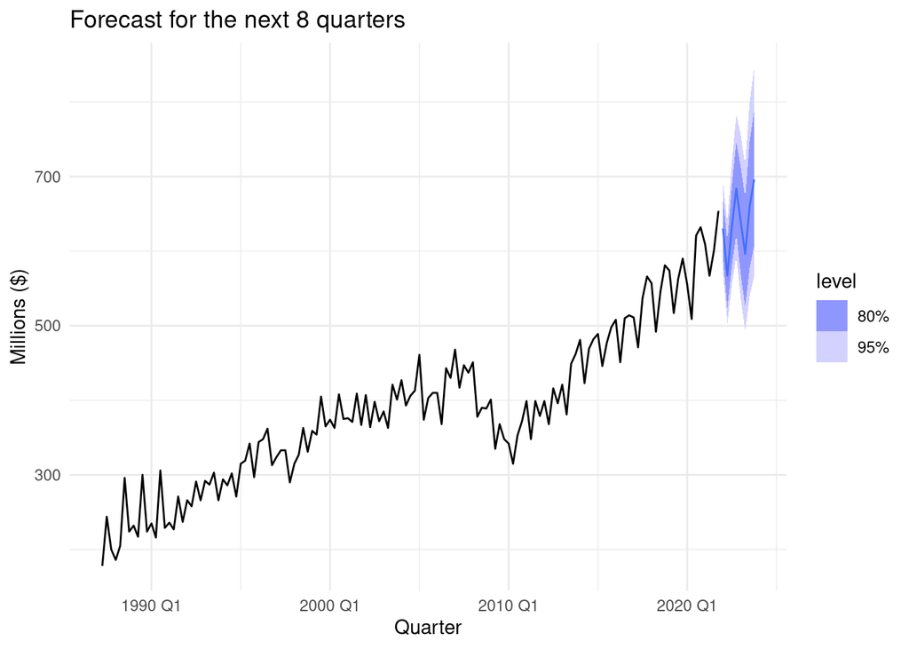

```r
ARIMA_forecast = fit %>%
  select(search) %>%
  forecast(h = 8)
ARIMA_forecast %>%
  autoplot(data) +
  labs(title = "Forecast for the next 8 quarters", x = "Quarter", y = "Millions ($)") +
  theme_minimal()
```

### Explain how prediction intervals are calculated for the method

A SARIMA model is denoted as ARIMA(p,d,q)(P,D,Q)[s].Once the SARIMA model is fitted, forecasts are generated. The forecast error variance for a given horizon ℎ considers both non-seasonal and seasonal components. The variance increases with the forecast horizon due to the accumulation of uncertainty over time. and prediction intervals increase as ℎ increases.

In Prediction intervals calculations, it assume residuals are uncorrelated and normally distributed. so the PI are based on the forecast error variance and the critical values from the standard normal distribution. If the model fails the assumption, like it fails the Ljung-Box test, the prediction intervals may not be accurate due to correlated residuals.

$$\hat{Y}_{t+h} \pm z_{\alpha/2} \cdot \sigma_h$$
Where: - $\hat{Y}_{t+h}$ is the forecasted value for time $t+h$. - $z_{\alpha/2}$ is the critical value from the standard normal distribution for the desired confidence level (e.g., 1.96 for 95% confidence). - $\sigma_h$ is the standard deviation of the forecast errors at horizon ℎ

# Neural Network Auto Regression Model

To understand how a Neural Network Auto Regression (NNAR) model works, its important to first understand the workings of a standard feed forward neural network.

### Understanding Neural Networks

A neural network is modelled after the way human brains work, in that each thought is a result of multiple different neurons firing. Neural networks act in a similar way, in that each prediction or output of the model is a result of several nodes or “neurons” combining their predictions together to come to a single prediction. In a feedforward neural network, the network is comprised of an input layer which includes the input data being fed into the model, optional hidden layers which taken in the output from the previous layer as input, and an output layer which returns the final prediction. The most basic neural network has no hidden layers, which acts the same as a linear regression model, since each input is given a weight, plus an additional bias (intercept) parameter. Hidden layers take the outputs of their preceding layers as inputs and then take a weighted linear sum of them, and alter them by a non linear function such as sigmoid or relu. These hidden layers allow non linearity to be captured by the model for more complicated relationships.

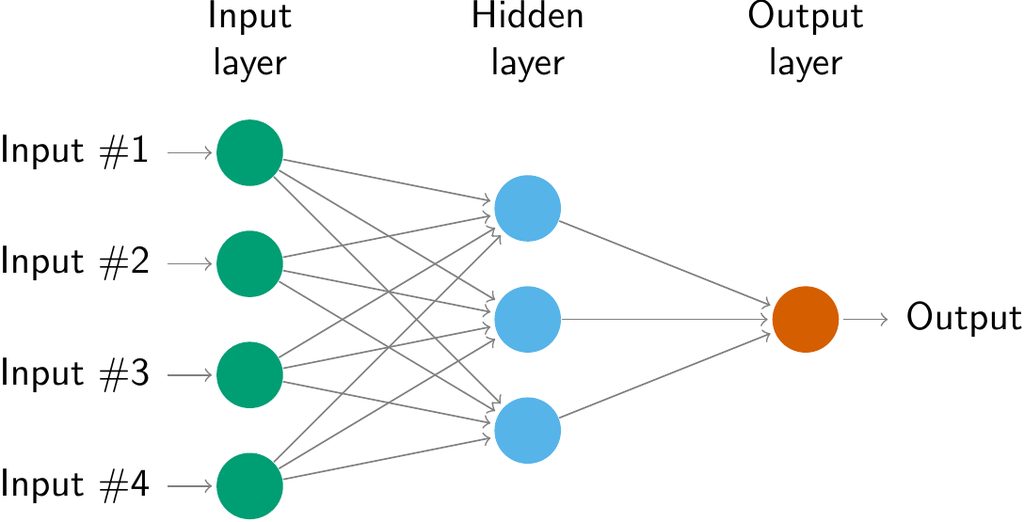

Example Neural Network

When training a feed forward neural network, each node in the network begins with random weights, which are then adjusted to minimize some metric - in the case of NNAR models this metric is MSE. Each iteration of training updates the weights of each node in the network, and then calculates the MSE of the models predictions when using these weights. The network then uses a process called back propagation to assess each node in the network to find which nodes were responsible for the most error in the result, so that in the next iteration these nodes can have their weights changed more drastically to improve the model as much as possible.

### Understanding the Neural Network Auto Regression Model

NNAR models are neural networks which take lagged values of the time series as inputs to the model in order to make predictions. These NNAR models can have many hidden layers, but we fit ours with just one in order to keep the model from being overly complicated. NNAR models are described by the notation NNAR(p, P, k), where p represents the amount of regular lagged inputs into the model, P represents the number of seasonal lags included as input to the model, and k is the number of neurons in the hidden layer. The easiest way to understand these parameters is by looking at an example.

Say we are fitting an NNAR(3,2,3) model on a dataset with yearly seasonality. Here we have a p parameter of 3, meaning in order to predict $y_n$, we will take the lagged inputs $y_{n-1}, y_{n-2}, y_{n-3}$. Additionally we have the P parameter of 2, meaning we will take the seasonal lags $y_{n-12}, y_{n-24}$. This means our model will have an input layer of 5 nodes which take in the lagged inputs $y_{n-1}, y_{n-2}, y_{n-3}, y_{n-12}, y_{n-24}$. Also since our model has a k parameter of 3, it means there is a hidden layer containing 3 neurons, which each take the outputs from the input layer as their respective inputs.

For our model we use the NNETAR() function to fit an NNAR model for us which will calculate optimal parameters for us. By default the model will determine p by fitting a linear model on the seasonally adjusted time series and taking the optimal number of lags according to AIC. The P parameter will automatically be set to 1, and the k parameter is set to (p + P + 1)/2.

## Model fitting

```r
NN.fit = data %>%
  model(base_model = NNETAR()) %>%
  report()
```

```
## Model not specified, defaulting to automatic modelling of the `FAAFFSS`
## variable. Override this using the model formula.
```

```
## Series: FAAFFSS
## Model: NNAR(1,1,2)[4]
##
## Average of 20 networks, each of which is
## a 2-2-1 network with 9 weights
## options were - linear output units
##
## sigma^2 estimated as 486.5
```

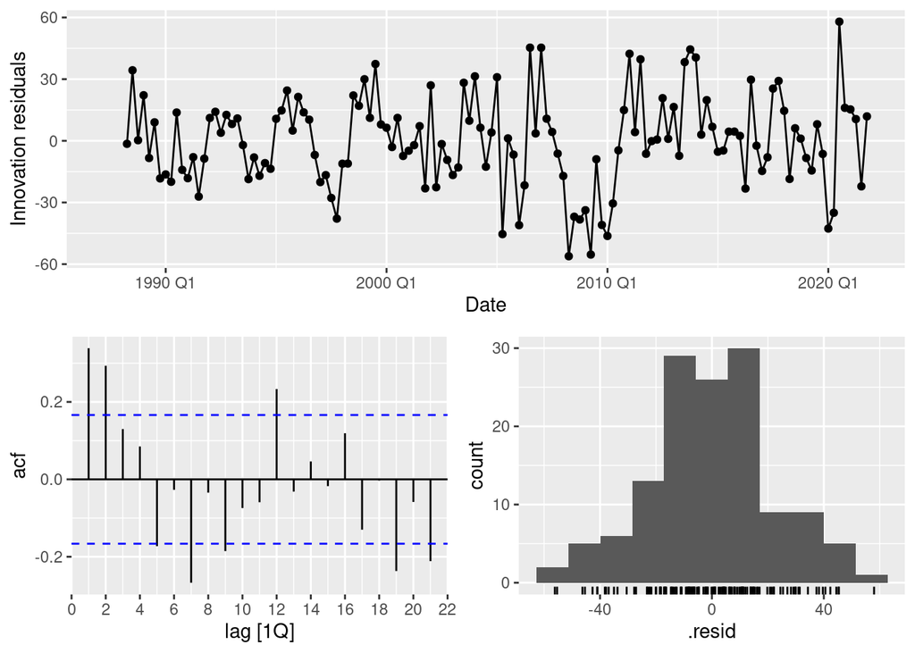

```r
NN.fit %>% gg_tsresiduals()
```

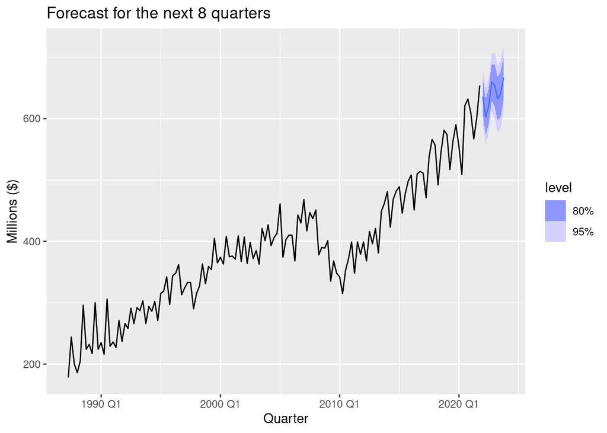

```r
NN_forecast = NN.fit %>%
  forecast(h=8)
NN_forecast %>%
  autoplot(data) +
  labs(title = "Forecast for the next 8 quarters", x = "Quarter", y = "Millions ($)")
```

### Report the fitted model

We can see the NNAR model was wit with p = 1, P = 1, and k = 2, following the method of parameter choice we discussed prior. This suggests that the optimal number of lags according to AIC must have been 1.

### Prediction Interval Calculation

Since the NNAR model is not based on a well defined stochastic model, there is not a straightforward method to calculate the prediction interval. To account for this, bootstrapping is done in order to determine the variability for each prediction.

The NNAR(1,1,2) model that we fit to the FAAFFSS data can be written as $y_t = f(z_{t-1}) + \epsilon_t$, where $z_t = (y_{t-1}, y_{t-4})$ where the errors $\epsilon_t$ are assumed to be normally distributed around zero. Using this assumption, we can use our model to make a prediction for the next time period $y_{t+1}$ and add a bootstrapped error, either drawn from the normal distribution or taken from the sample of errors we saw in the training set. If we do this several times (The forecast function does it 1000 times by default) then we can approximate the prediction interval by finding the band which contains 80% and 95% of (predictions + errors) at the next time period. This process can be repeated for as many forecast periods as we like by using the most recent prediction as the input for the new predictions.

# Assumption checking.

Surrogate data testing is a method used in time series analysis to check whether the data can be described by a linear process. We first assume the data follows a linear process, then create several surrogate datasets using the original dataset through Monte Carlo methods.

A common way to create these surrogate datasets is the Random Shuffle method, where surrogate data is generated from shuffling the original data like a deck of cards. This method destroys any temporal structure or pattern but keeps the overall distribution of values untouched.

If the original data had some kind of significant structure or pattern, it should stand out when compared to the shuffled surrogate data.

```r
# Run surrogate test on the data
s = surrogate.test(data, lag = 8)
print(paste0("P-value for Ljung-Box statistic: ", s$p.value))
```

```
## [1] "P-value for Ljung-Box statistic: 0"
```

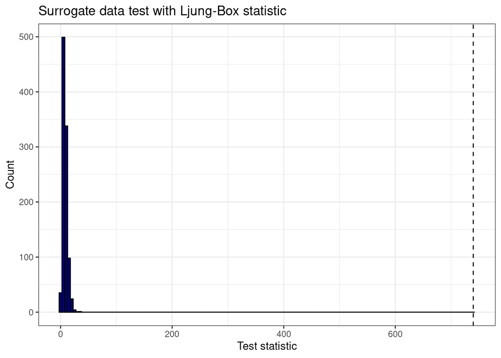

```r
s %>%
  plot.surrogate(binwidth = 5) +
  theme_bw() +
  labs(title = "Surrogate data test with Ljung-Box statistic")
```

```r
p = surrogate.test(data, lag = 8, test.stat = "box-pierce")
print(paste0("P-value for Box-Pierce statistic: ", p$p.value))
```

```
## [1] "P-value for Box-Pierce statistic: 0"
```

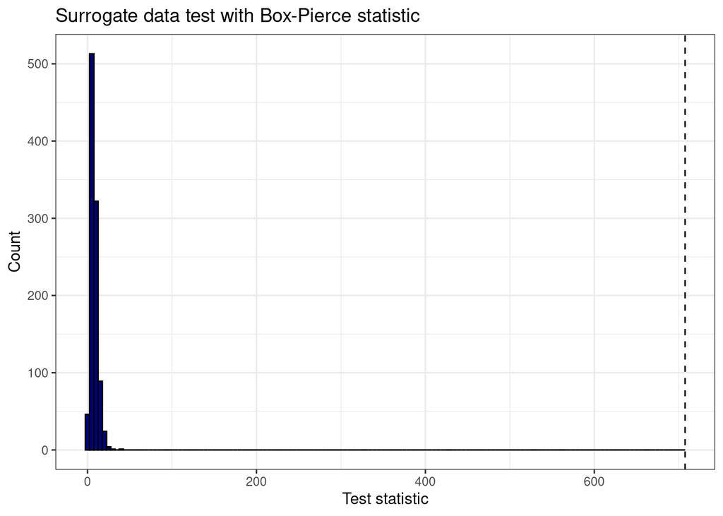

```r
p %>%
  plot.surrogate(binwidth = 5) +
  theme_bw() +
  labs(title = "Surrogate data test with Box-Pierce statistic")
```

### Explaining the r code

Surrogate.test calculates the observed test statistic and the null distribution according to the test statistic chosen. The observed test statistic is calculated using the autocorrelation function of the data. The null distribution is generated by permuting the data and calculating the test statistic for each permutation.

The p-value is then calculated as the proportion of the null distribution that is greater than or equal to the observed test statistic.

The function returns a list containing the null distribution, the observed test statistic, the test statistic used, and the p-value.

The plot.surrogate() function plots the surrogate null distribution and the observed test statistic, using the output from surrogate.test. A histogram is plotted for the surrogate test statistics and a vertical dashed line is plotted for the observed test statistic calculated from the original data. I modified this to include a parameter for the histogram bar width.

# Forecasting accuracy

```r
full_data = read_csv("qgdp_full.csv")
full_data = full_data %>% mutate(Date = yearquarter(Date)) %>%
  select(Date, `Fishing, Aquaculture and Agriculture, Forestry and Fishing Support Services`) %>%
  rename(FAAFFSS = `Fishing, Aquaculture and Agriculture, Forestry and Fishing Support Services`)
full_data = full_data %>%
 as_tsibble(index = Date)

rbind(
  as.matrix(accuracy(forecast_data, full_data)),
  as.matrix(accuracy(ARIMA_forecast, full_data)),
  as.matrix(accuracy(NN_forecast, full_data))
) %>%
  knitr::kable()
```

| .model | .type | ME | RMSE | MAE | MPE | MAPE | MASE | RMSSE | ACF1 |
| --- | --- | --- | --- | --- | --- | --- | --- | --- | --- |
| ETS(FAAFFSS ~ error(“M”) + trend(“A”) + season(“M”)) | Test | 9.280548 | 19.54906 | 16.67565 | 1.539261 | 2.654215 | 0.7236298 | 0.6872077 | 0.1490431 |
| search | Test | -0.3278218 | 20.05912 | 17.06621 | 0.04364299 | 2.687593 | 0.7405782 | 0.7051378 | 0.1612757 |
| base_model | Test | -1.102817 | 10.13577 | 7.001991 | -0.190871 | 1.109365 | 0.3038473 | 0.3563025 | 0.2603142 |

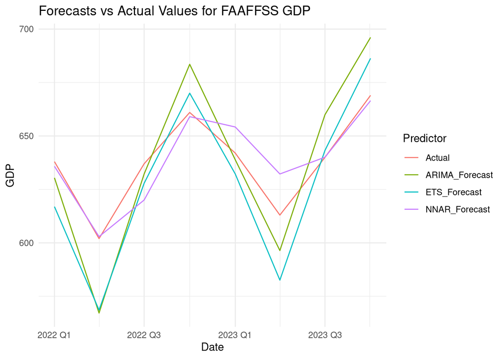

```r
all_forecasts = test_data_subset %>%
  left_join(forecast_data, by = "Date") %>%
  rename(ETS_Forecast = .mean, Actual = FAAFFSS.x) %>%
  left_join(ARIMA_forecast, by = "Date") %>%
  rename(ARIMA_Forecast = .mean) %>%
  left_join(NN_forecast, by = "Date") %>%
  rename(NNAR_Forecast = .mean) %>%
  select(Date,
         ETS_Forecast,
         ARIMA_Forecast,
         NNAR_Forecast,
         Actual)

# Plot forecasts vs actual values
all_forecasts %>%
  pivot_longer(cols = -Date, names_to = "Predictor", values_to = "Value") %>%
  ggplot(aes(x = Date, y = Value, color = Predictor)) +
  geom_line() +
  labs(title = "Forecasts vs Actual Values for FAAFFSS GDP", x = "Date", y = "GDP") +
  theme_minimal()
```

# Member Contributions

## Yuan (ych150)

- ARIMA implementation & writeup
- Assisted with managing github

## Stephen (shal797)

- NNAR Implementation & writeup
- Managing meetings, github & submission
- Final touch ups and collation

## Yuxiao (wany441)

- ETS implementation & writeup
- Assisted with test set forecast comparisons

## Bill (wany803)

- Exploratory analysis
- Assumption checking
- Test set forecast comparisons